# GPT_Markdown

Wesley H

2023-07-17

Load libraries:

```r
library(ggplot2)
library(dplyr)
library(readr)
library(tidyverse)
```

Load data and preview:

```r
benchmark <- read.csv("Benchmark.csv", header = TRUE)
tweets <- read.csv("BitcoinGPT.csv", header = TRUE)
```

## Analysis

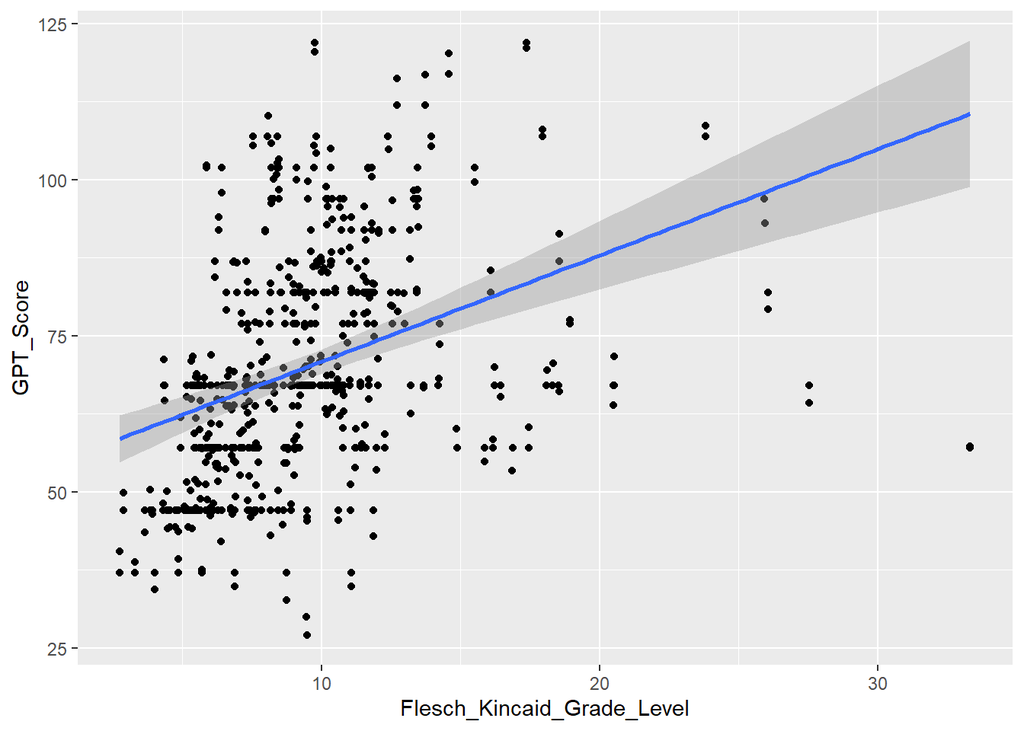

```r
ggplot(data = benchmark,
       mapping = aes(
         x = Flesch_Kincaid_Grade_Level,
         y = GPT_Score)) +
  geom_point()+
  geom_jitter(height=5)+
  geom_smooth(method = lm, formula = y ~ x, se = TRUE)
```

This plot graphs the GPT score against the Flesh_Kincaid assessment of the CLEAR Corpus assessments, and while they aren’t identical in their measurement style the trend remains the same; a higher number indicates something more difficult to read.

For more details on the Clear Corpus dataset and a link to download the original data set used please visit https://github.com/scrosseye/CLEAR-Corpus

```r
correlation <- cor(benchmark$Flesch_Kincaid_Grade_Level, benchmark$GPT_Score)
print(correlation)
```

```
## [1] 0.3721114
```

Calculate the exact correlation, print. My research resulted in a correlation of 0.3721114, however, if you replicate the analysis with the same text, but re-run through GPT the score will likely be different, as the LLM isn’t consistent with ratings.

```r
df <- data.frame(tweets$user_verified, tweets$GPT_Score)
```

Note: due to some tweets being completely comprised of stock tickers and emojis, a FKGL score was not given by GPT, reassigning the variables to an independent data frame removes null inputs.

[output not shown]

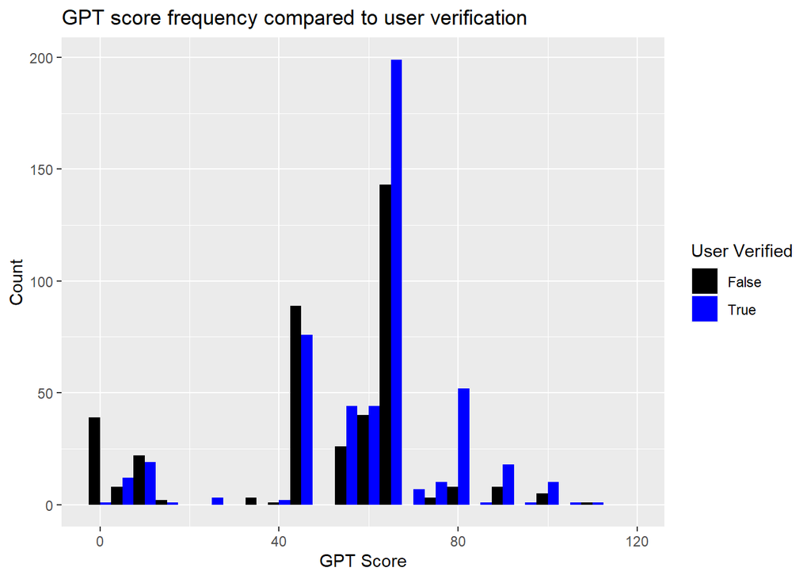

```r
ggplot(df, aes(fill = tweets.user_verified, x = tweets.GPT_Score)) +
  geom_histogram(binwidth = 5, position = "dodge") +
  labs(title = "GPT score frequency compared to user verification", x = "GPT Score", y = "Count") +
  scale_fill_manual(name = "User Verified", values = c("black", "blue")) +
  coord_cartesian(ylim = c(NA, 350))+
  coord_cartesian(xlim = c(NA, 120))
```

A graph of GPT score frequency, breaking out scores based on user verification to look for an obvious trend or weight that user verification has on this proxy for tweet quality.

```r
#Average scores
average_scores <- aggregate(tweets.GPT_Score ~ tweets.user_verified, data = df, FUN = mean)
print(average_scores)
```

```
##   tweets.user_verified tweets.GPT_Score
## 1                False         58.28571
## 2                 True         62.13546
```

```r
#Median scores
median_scores <- aggregate(tweets.GPT_Score ~ tweets.user_verified, data = df, FUN = median)
print(median_scores)
```

```
##   tweets.user_verified tweets.GPT_Score
## 1                False               62
## 2                 True               67
```

Due to how unclear the trend is in the visuals, calculate averages and medians